# Time Series Forecasting of Energy Consumption in Romania

# ======================================================

# STEP 7: STL MODEL (Seasonal-Trend Decomposition using Loess)

# ======================================================

```r
#Create the time series object
#Using daily consumption data with yearly frequency (365 observations per year)
cons_ts <- ts(daily_cons_data$Consumption, start = c(2019, 1), frequency = 365)

#Split data into training and test sets (60 days)
train <- head(daily_cons_data$Consumption, -60)
test  <- tail(daily_cons_data$Consumption, 60)
train_ts <- ts(train, frequency = 365)

#Fit the STL model and forecast
#stlf() function automatically decomposes the series into seasonal, trend, and remainder components and fits an ETS model on the seasonally adjusted data.
fit_train_stl <- stlf(train_ts, h = 60)

#Evaluate STL model accuracy
accuracy_results_stl <- accuracy(fit_train_stl$mean, test)
accuracy_results_stl
```

```
##                ME     RMSE     MAE        MPE     MAPE
## Test set 5.815144 594.3855 483.678 -0.6615085 7.345804
```

```r
#Compare STL and ARIMA performance
accuracy_comparison <- rbind(
  ARIMA = accuracy_results_arima_60[1, c("RMSE", "MAE", "MAPE")],
  STL   = accuracy_results_stl[1, c("RMSE", "MAE", "MAPE")]
)
accuracy_comparison
```

```
##           RMSE      MAE     MAPE
## ARIMA 689.3279 524.1736 8.355127
## STL   594.3855 483.6780 7.345804
```

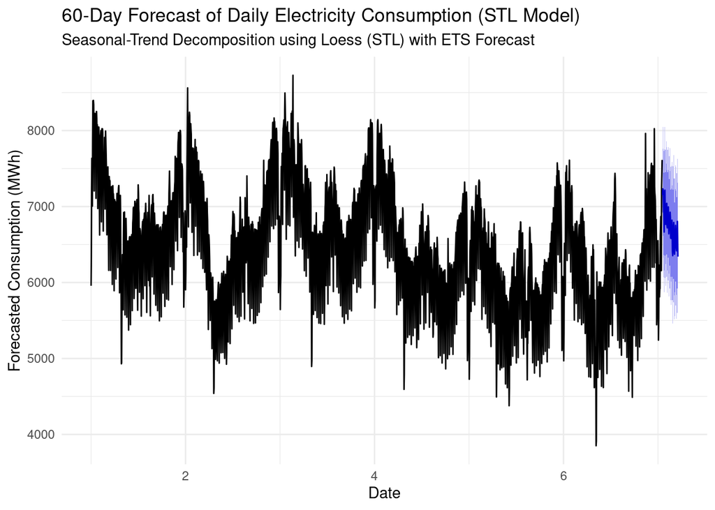

```r
#Plot the STL forecast
autoplot(fit_train_stl) +
  labs(
    title = "60-Day Forecast of Daily Electricity Consumption (STL Model)",
    subtitle = "Seasonal-Trend Decomposition using Loess (STL) with ETS Forecast",
    x = "Date",
    y = "Forecasted Consumption (MWh)"
  ) +
  theme_minimal()
```

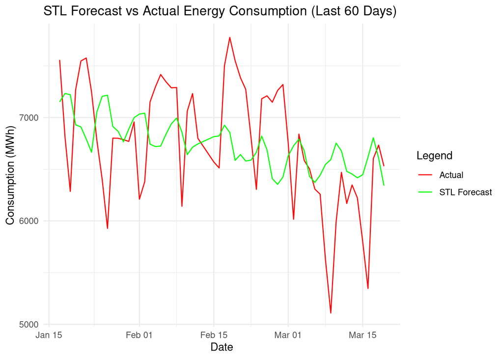

```r
#Visual comparison: Actual vs STL forecast
forecast_df_stl <- data.frame(
  Date = tail(daily_cons_data$Date, 60),
  Actual = test,
  Forecast = as.numeric(fit_train_stl$mean)
)

ggplot(forecast_df_stl, aes(x = Date)) +
  geom_line(aes(y = Actual, color = "Actual")) +
  geom_line(aes(y = Forecast, color = "STL Forecast")) +
  labs(
    title = "STL Forecast vs Actual Energy Consumption (Last 60 Days)",
    x = "Date",
    y = "Consumption (MWh)",
    color = "Legend"
  ) +
  scale_color_manual(values = c("Actual" = "red", "STL Forecast" = "green")) +
  theme_minimal()
```

#The STL model was applied to the same dataset to explicitly capture the trend, seasonal, and irregular components of daily electricity consumption. Unlike ARIMA, STL decomposes the time series before forecasting, allowing it to adapt more effectively to recurring seasonal patterns.

#Model evaluation results confirm that STL performs better than ARIMA, achieving lower error metrics (RMSE = 594, MAE = 484, MAPE = 7.35% versus ARIMA’s 8.36%). This indicates a more accurate and seasonally responsive model, making STL a stronger choice for short-term electricity consumption forecasting in Romania.

# ======================================================

# STEP 8: MODEL COMPARISON AND CONCLUSION

# ======================================================

#Model Comparison

#Two models, namely ARIMA(5,1,2) and STL, were developed to forecast Romania’s daily electricity consumption over a 60-day period.

#ARIMA(5,1,2): RMSE = 689.33; MAE = 524.17; MAPE = 8.36% #STL : RMSE = 594.39; MAE: 483.68; MAPE = 7.35%

#The STL model achieved lower error values across all three metrics, indicating better fit and forecast precision. Its ability to handle strong seasonality and smooth long-term trends makes it particularly suitable for energy demand forecasting.

#In contrast, the ARIMA model, while still robust, tended to smooth short-term fluctuations and slightly underestimate rapid changes in consumption.

#====================================================== #Conclusion #======================================================

#Both ARIMA and STL models demonstrate that Romania’s electricity consumption is highly seasonal but stable over time, with consistent winter peaks and summer troughs.

#The STL model proved to be the more reliable forecasting approach, reducing the average forecast error to about 7%.

#For short-term (1–3 month) planning, STL provides realistic and interpretable predictions that can support energy management, grid operations, and policy decisions.